```python
import numpy as np
import pandas as pd
import matplotlib.pyplot as plt
import seaborn as sns
import math
# import datetime
import time
import warnings
warnings.filterwarnings('ignore')
sns.set_style('whitegrid')
pd.set_option('display.max_columns', None)
pd.set_option('display.max_rows', 1000)

import os, ssl
if (not os.environ.get('PYTHONHTTPSVERIFY', '') and
    getattr(ssl, '_create_unverified_context', None)):
    ssl._create_default_https_context = ssl._create_unverified_context
```

sumber data: https://www.kaggle.com/jealousleopard/goodreadsbooks

# Tujuan:

- Memberikan rekomendasi judul buku dari top 20 berdasarkan jumlah halaman buku, pembaca yang paling banyak memberikan rating, pembaca yang paling banyak memberikan review buku
- Memberikan rekomendasi penulis dari top 20 feature berdasarkan jumlah halaman buku, pembaca yang paling banyak memberikan rating, pembaca yang paling banyak memberikan review buku
- Memberikan Trusted Rating buku yang harus dibaca sesuai trend yang dibaca banyak subscriber Goodreads

# Permasalahan

- Rating tinggi tidak menjamin bukunya recommended karena jumlah pemberi rating bisa saja hanya 1 orang
- Review Goodreads tidak disebutkan apakah review positif atau review negatif sehingga kalimat review yang banyak tidak menjamin review tersebut merupakan review atau komentar yang positif dan dapat direkomendasikan untuk pembaca lain

```python
df = pd.read_csv('books.csv', error_bad_lines=False, parse_dates=['publication_date'])

df['publication_date'] = pd.to_datetime(df['publication_date'], format='%m/%d/%Y', errors='coerce')
df['Tanggal'] = df['publication_date'].dt.day.astype('Int64')
df['Month'] = df['publication_date'].dt.month.astype('Int64')
df['Year'] = df['publication_date'].dt.year.astype('Int64')

# kolom Trending dihitung darijumlah orang yang memberikan rating dikali text_reviews_count
df['Trending'] = df['ratings_count']* df['text_reviews_count']

df.head()
```

```
b'Skipping line 3350: expected 12 fields, saw 13\nSkipping line 4704: expected 12 fields, saw 13\nSkipping line 5879: expected 12 fields, saw 13\nSkipping line 8981: expected 12 fields, saw 13\n'
```

|  | bookID | title | authors | average_rating | isbn | isbn13 | language_code | num_pages | ratings_count | text_reviews_count | publication_date | publisher | Tanggal | Month | Year | Trending |
| --- | --- | --- | --- | --- | --- | --- | --- | --- | --- | --- | --- | --- | --- | --- | --- | --- |
| 0 | 1 | Harry Potter and the Half-Blood Prince (Harry ... | J.K. Rowling/Mary GrandPré | 4.57 | 0439785960 | 9780439785969 | eng | 652 | 2095690 | 27591 | 2006-09-16 | Scholastic Inc. | 16 | 9 | 2006 | 57822182790 |
| 1 | 2 | Harry Potter and the Order of the Phoenix (Har... | J.K. Rowling/Mary GrandPré | 4.49 | 0439358078 | 9780439358071 | eng | 870 | 2153167 | 29221 | 2004-09-01 | Scholastic Inc. | 1 | 9 | 2004 | 62917692907 |
| 2 | 4 | Harry Potter and the Chamber of Secrets (Harry... | J.K. Rowling | 4.42 | 0439554896 | 9780439554893 | eng | 352 | 6333 | 244 | 2003-11-01 | Scholastic | 1 | 11 | 2003 | 1545252 |
| 3 | 5 | Harry Potter and the Prisoner of Azkaban (Harr... | J.K. Rowling/Mary GrandPré | 4.56 | 043965548X | 9780439655484 | eng | 435 | 2339585 | 36325 | 2004-05-01 | Scholastic Inc. | 1 | 5 | 2004 | 84985425125 |
| 4 | 8 | Harry Potter Boxed Set Books 1-5 (Harry Potte... | J.K. Rowling/Mary GrandPré | 4.78 | 0439682584 | 9780439682589 | eng | 2690 | 41428 | 164 | 2004-09-13 | Scholastic | 13 | 9 | 2004 | 6794192 |

```python
df.tail()
```

|  | bookID | title | authors | average_rating | isbn | isbn13 | language_code | num_pages | ratings_count | text_reviews_count | publication_date | publisher | Tanggal | Month | Year | Trending |
| --- | --- | --- | --- | --- | --- | --- | --- | --- | --- | --- | --- | --- | --- | --- | --- | --- |
| 11118 | 45631 | Expelled from Eden: A William T. Vollmann Reader | William T. Vollmann/Larry McCaffery/Michael He... | 4.06 | 1560254416 | 9781560254416 | eng | 512 | 156 | 20 | 2004-12-21 | Da Capo Press | 21 | 12 | 2004 | 3120 |
| 11119 | 45633 | You Bright and Risen Angels | William T. Vollmann | 4.08 | 0140110879 | 9780140110876 | eng | 635 | 783 | 56 | 1988-12-01 | Penguin Books | 1 | 12 | 1988 | 43848 |
| 11120 | 45634 | The Ice-Shirt (Seven Dreams #1) | William T. Vollmann | 3.96 | 0140131965 | 9780140131963 | eng | 415 | 820 | 95 | 1993-08-01 | Penguin Books | 1 | 8 | 1993 | 77900 |
| 11121 | 45639 | Poor People | William T. Vollmann | 3.72 | 0060878827 | 9780060878825 | eng | 434 | 769 | 139 | 2007-02-27 | Ecco | 27 | 2 | 2007 | 106891 |
| 11122 | 45641 | Las aventuras de Tom Sawyer | Mark Twain | 3.91 | 8497646983 | 9788497646987 | spa | 272 | 113 | 12 | 2006-05-28 | Edimat Libros | 28 | 5 | 2006 | 1356 |

```python
df.shape
```

```
(11123, 16)
```

```python
df.describe()
```

|  | bookID | average_rating | isbn13 | num_pages | ratings_count | text_reviews_count | Tanggal | Month | Year | Trending |
| --- | --- | --- | --- | --- | --- | --- | --- | --- | --- | --- |
| count | 11123.000000 | 11123.000000 | 1.112300e+04 | 11123.000000 | 1.112300e+04 | 11123.000000 | 11121.000000 | 11121.000000 | 11121.000000 | 1.112300e+04 |
| mean | 21310.856963 | 3.934075 | 9.759880e+12 | 336.405556 | 1.794285e+04 | 542.048099 | 11.258700 | 6.547523 | 2000.170668 | 2.607221e+08 |
| std | 13094.727252 | 0.350485 | 4.429758e+11 | 241.152626 | 1.124992e+05 | 2576.619589 | 10.280625 | 3.413989 | 8.246168 | 5.251710e+09 |
| min | 1.000000 | 0.000000 | 8.987060e+09 | 0.000000 | 0.000000e+00 | 0.000000 | 1.000000 | 1.000000 | 1900.000000 | 0.000000e+00 |
| 25% | 10277.500000 | 3.770000 | 9.780345e+12 | 192.000000 | 1.040000e+02 | 9.000000 | 1.000000 | 4.000000 | 1998.000000 | 9.755000e+02 |
| 50% | 20287.000000 | 3.960000 | 9.780582e+12 | 299.000000 | 7.450000e+02 | 47.000000 | 8.000000 | 7.000000 | 2003.000000 | 3.526000e+04 |
| 75% | 32104.500000 | 4.140000 | 9.780872e+12 | 416.000000 | 5.000500e+03 | 238.000000 | 20.000000 | 10.000000 | 2005.000000 | 1.149552e+06 |
| max | 45641.000000 | 5.000000 | 9.790008e+12 | 6576.000000 | 4.597666e+06 | 94265.000000 | 31.000000 | 12.000000 | 2020.000000 | 4.333990e+11 |

```python
df.info()
```

```
<class 'pandas.core.frame.DataFrame'>
RangeIndex: 11123 entries, 0 to 11122
Data columns (total 16 columns):
 #   Column              Non-Null Count  Dtype
---  ------              --------------  -----
 0   bookID              11123 non-null  int64
 1   title               11123 non-null  object
 2   authors             11123 non-null  object
 3   average_rating      11123 non-null  float64
 4   isbn                11123 non-null  object
 5   isbn13              11123 non-null  int64
 6   language_code       11123 non-null  object
 7     num_pages         11123 non-null  int64
 8   ratings_count       11123 non-null  int64
 9   text_reviews_count  11123 non-null  int64
 10  publication_date    11121 non-null  datetime64[ns]
 11  publisher           11123 non-null  object
 12  Tanggal             11121 non-null  Int64
 13  Month               11121 non-null  Int64
 14  Year                11121 non-null  Int64
 15  Trending            11123 non-null  int64
dtypes: Int64(3), datetime64[ns](1), float64(1), int64(6), object(5)
memory usage: 1.4+ MB
```

```python
df.dtypes
```

```
bookID                         int64
title                         object
authors                       object
average_rating               float64
isbn                          object
isbn13                         int64
language_code                 object
  num_pages                    int64
ratings_count                  int64
text_reviews_count             int64
publication_date      datetime64[ns]
publisher                     object
Tanggal                        Int64
Month                          Int64
Year                           Int64
Trending                       int64
dtype: object
```

```python
df.nunique()
```

```
bookID                11123
title                 10348
authors                6639
average_rating          209
isbn                  11123
isbn13                11123
language_code            27
  num_pages             997
ratings_count          5294
text_reviews_count     1822
publication_date       3677
publisher              2290
Tanggal                  31
Month                    12
Year                     87
Trending               8283
dtype: int64
```

```python
df.isnull().sum()
```

```
bookID                0
title                 0
authors               0
average_rating        0
isbn                  0
isbn13                0
language_code         0
  num_pages           0
ratings_count         0
text_reviews_count    0
publication_date      2
publisher             0
Tanggal               2
Month                 2
Year                  2
Trending              0
dtype: int64
```

```python
df.dropna(inplace=True)
```

```python
df.isnull().sum()
```

```
bookID                0
title                 0
authors               0
average_rating        0
isbn                  0
isbn13                0
language_code         0
  num_pages           0
ratings_count         0
text_reviews_count    0
publication_date      0
publisher             0
Tanggal               0
Month                 0
Year                  0
Trending              0
dtype: int64
```

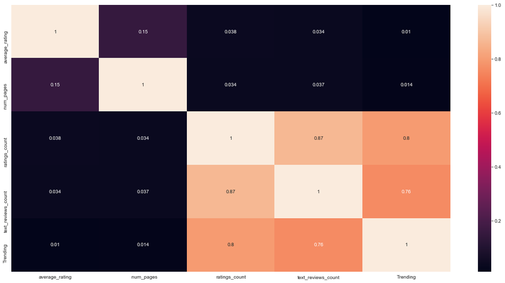

```python
plt.figure(figsize=(20,10))
sns.heatmap(df.drop(columns=['Tanggal', 'Month', 'Year', 'bookID', 'isbn13']).corr(), annot=True)
plt.show()
```

- Kolom target adalah average_rating.  
  - Kolom yang memiliki korelasi yang cukup besar dengan average_rating adalah num_pages  
  - Selanjutnya akan dicari hubungan antara average_rating dengan text_reviewers_count, ratings_count dan num_pages  
  *feature Trending tidak dipilih karena korelasinya kecil terhadap average_rating

## Analisis Data

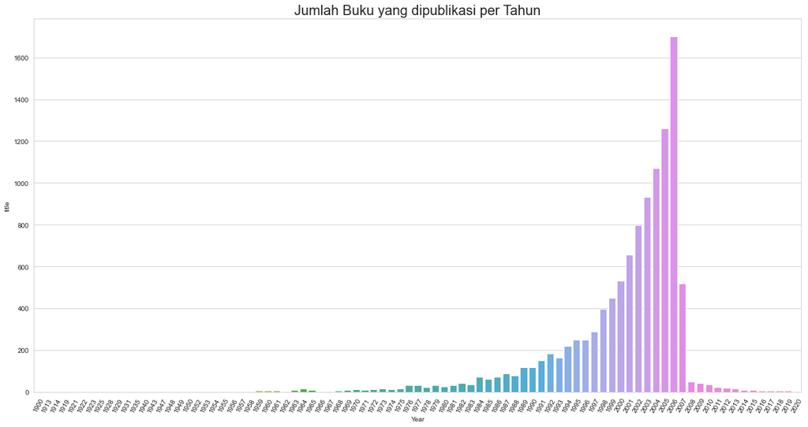

```python
x = df.pivot_table(index='Year', values='title', aggfunc='count').reset_index()
plt.figure(figsize=(20, 10))
ax = sns.barplot(x="Year", y="title", data=x)
plt.title('Jumlah Buku yang dipublikasi per Tahun', fontsize=20)
plt.xticks(rotation=60)
plt.show()
```

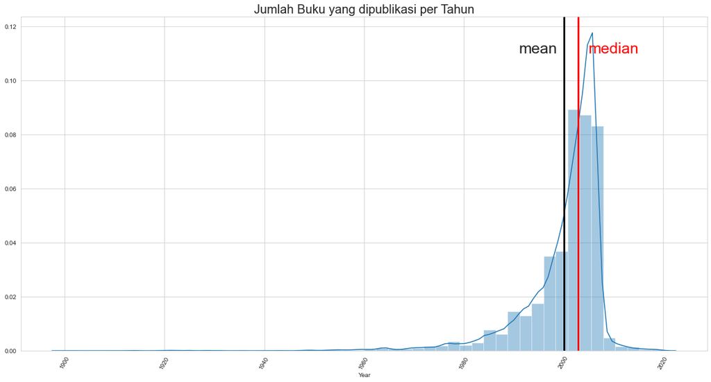

```python
plt.figure(figsize=(20, 10))
ax = sns.distplot(df['Year'])
plt.title('Jumlah Buku yang dipublikasi per Tahun', fontsize=20)
plt.text(1991, 0.11, 'mean', fontsize=25,)
plt.axvline(x=df['Year'].mean(), linewidth=3, color = 'k')
plt.text(2005, 0.11, 'median', fontsize=25, color='r')
plt.axvline(x=df['Year'].median(), linewidth=3, color = 'r')
plt.xticks(rotation=60)
plt.show()
```

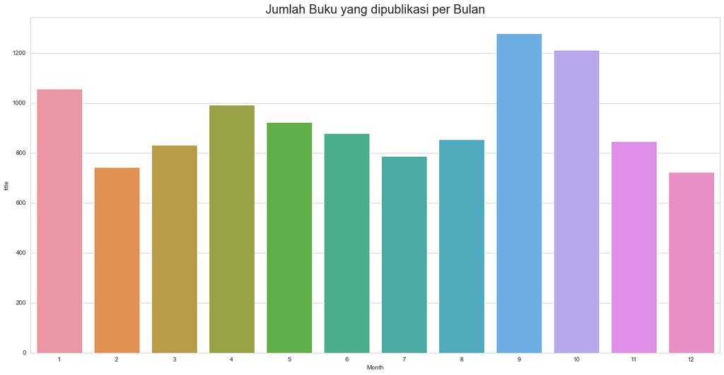

```python
y = df.pivot_table(index='Month', values='title', aggfunc='count').reset_index()
plt.figure(figsize=(20, 10))
ax = sns.barplot(x="Month", y="title", data=y)
plt.title('Jumlah Buku yang dipublikasi per Bulan', fontsize=20)
plt.show()
```

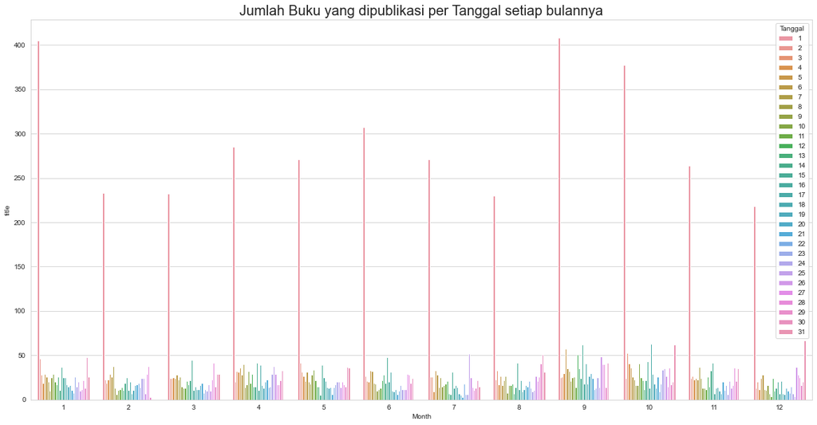

```python
y = df.pivot_table(index=['Month', 'Tanggal'], values='title', aggfunc='count').reset_index()
plt.figure(figsize=(20, 10))
ax = sns.barplot(x="Month", y="title", hue='Tanggal', data=y)
plt.title('Jumlah Buku yang dipublikasi per Tanggal setiap bulannya', fontsize=20)
plt.show()
```

Publikasi buku di Goodreads paling banyak dilakukan setiap tanggal 1 setiap bulannya.

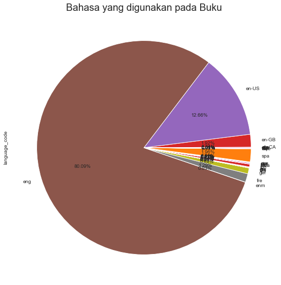

```python
plt.figure(figsize=(20, 10))
df.groupby('language_code')['language_code'].count().plot(kind='pie', autopct='%1.2f%%')
plt.title('Bahasa yang digunakan pada Buku', fontsize=20)
plt.show()
```

-- Tiga buku yang direview terbesar adalah buku berbahasa Inggris

## Buku yang paling banyak dirating (ratings_count)

[figure not shown]

```python
c = df.sort_values(by='ratings_count', ascending=False).iloc[:20, :]
plt.figure(figsize=(15, 10))
ax = sns.barplot(x="ratings_count", y="title", data=c)
plt.title('20 buku yang paling banyak dirating oleh pembaca di Goodreads', fontsize=20)
plt.yticks(fontsize=15)
plt.show()
```

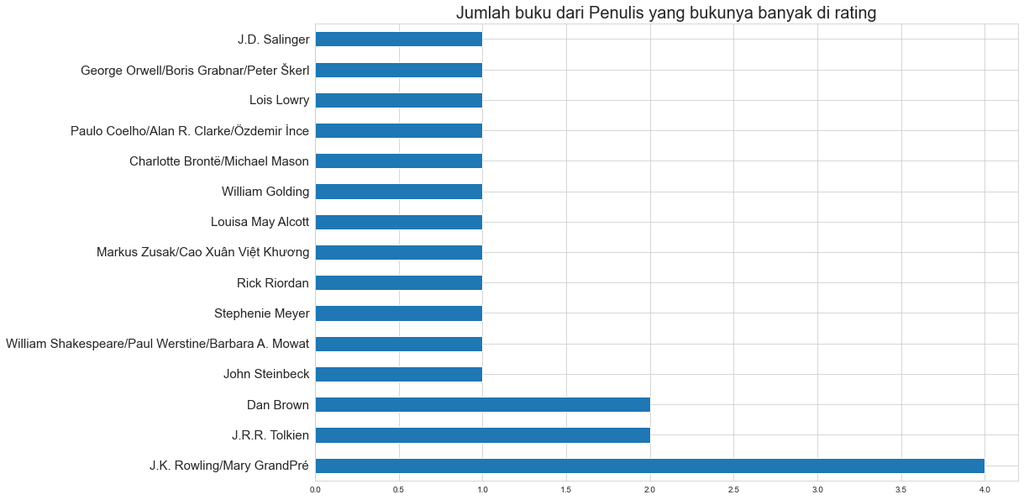

```python
plt.figure(figsize=(15, 10))
c['authors'].value_counts().plot(kind='barh')
plt.title('Jumlah buku dari Penulis yang bukunya banyak di rating', fontsize=20)
plt.yticks(fontsize=15)
plt.show()
```

J.K. Rowling/Mary GrandPré merupakan penulis yang memiliki 4 buku yang sering diberikan rating oleh pembaca di Goodreads, disusul oleh Dan Brown dan J.R.R Tolkien

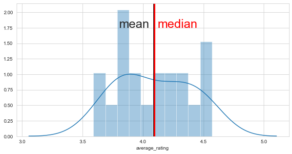

```python
plt.figure(figsize=(10, 5))
ax = sns.distplot(c['average_rating'], bins=10)
plt.text(3.8, 1.75, 'mean', fontsize=25,)
plt.axvline(x=c['average_rating'].mean(), linewidth=3, color = 'k')
plt.text(4.12, 1.75, 'median', fontsize=25, color='r')
plt.axvline(x=c['average_rating'].median(), linewidth=3, color = 'r')
plt.show()
```

Pada buku top 20 paling banyak diberikan rating, rata-rata rating hampir membentuk distribusi Gaussian. Nilai mean dapat merepresentasikan berapa rata-rata dari average_rating buku yang paling banyak diberi rating

```python
# Nilai rata-rata average_rating buku yang paling banyak di rating
c['average_rating'].mean()
```

```
4.0905000000000005
```

Buku-buku yang paling banyak diberikan rating memiliki average_rating rata-rata 4.09

# Jumlah halaman buku

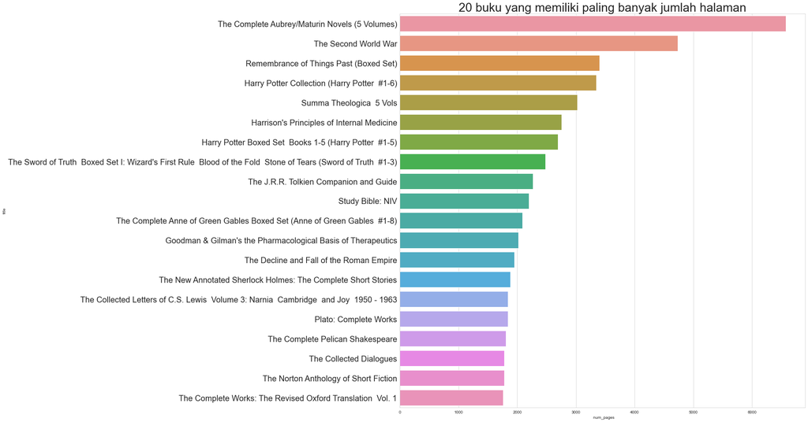

```python
d = df.sort_values(by='  num_pages', ascending=False).iloc[:20, :]
d['authors'] = d['authors'].apply(lambda x: x.split('/')[0] + ' / and alias')
plt.figure(figsize=(18, 18))
ax = sns.barplot(x="  num_pages", y="title", data=d)
plt.title('20 buku yang memiliki paling banyak jumlah halaman', fontsize=30)
plt.yticks(fontsize=20)
plt.show()
```

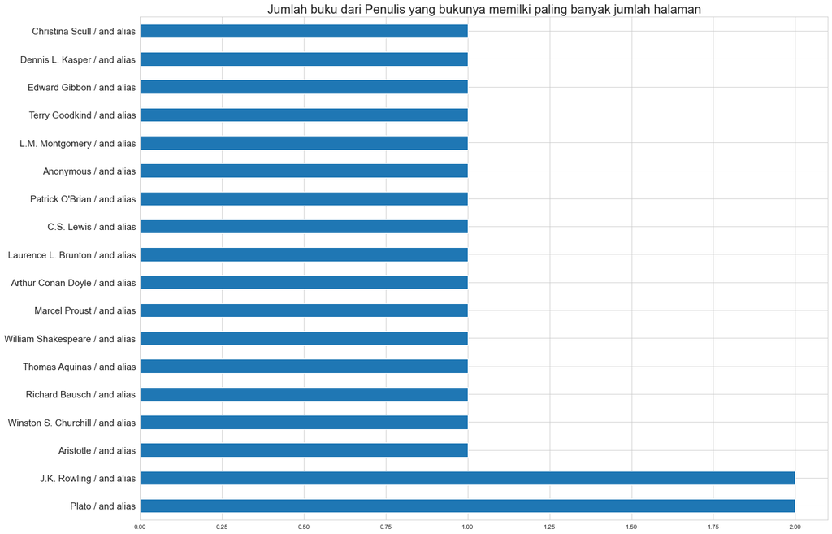

```python
plt.figure(figsize=(20, 15))
d['authors'].value_counts().plot(kind='barh')
plt.title('Jumlah buku dari Penulis yang bukunya memilki paling banyak jumlah halaman', fontsize=20)
plt.yticks(fontsize=15)
plt.show()
```

J.K. Rowling dan Plato memiliki 2 buku yang top 20 halaman terbanyak. Title dari buku penulis tersebut merupakan buku series complete (terdiri dari banyak bab atau season)

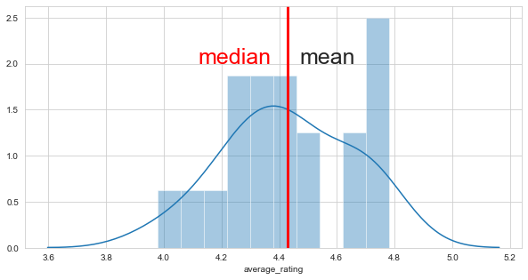

```python
plt.figure(figsize=(10, 5))
ax = sns.distplot(d['average_rating'], bins=10)
plt.text(4.47, 2, 'mean', fontsize=25,)
plt.axvline(x=d['average_rating'].mean(), linewidth=3, color = 'k')
plt.text(4.12, 2, 'median', fontsize=25, color='r')
plt.axvline(x=d['average_rating'].median(), linewidth=3, color = 'r')
plt.show()
```

Pada buku top 20 paling banyak jumlah halaman, rata-rata rating hampir membentuk distribusi Gaussian. Nilai mean dapat merepresentasikan berapa rata-rata dari average_rating buku yang memiliki banyak halaman

```python
d['average_rating'].median()
```

```
4.43
```

# Panjang Kata Review

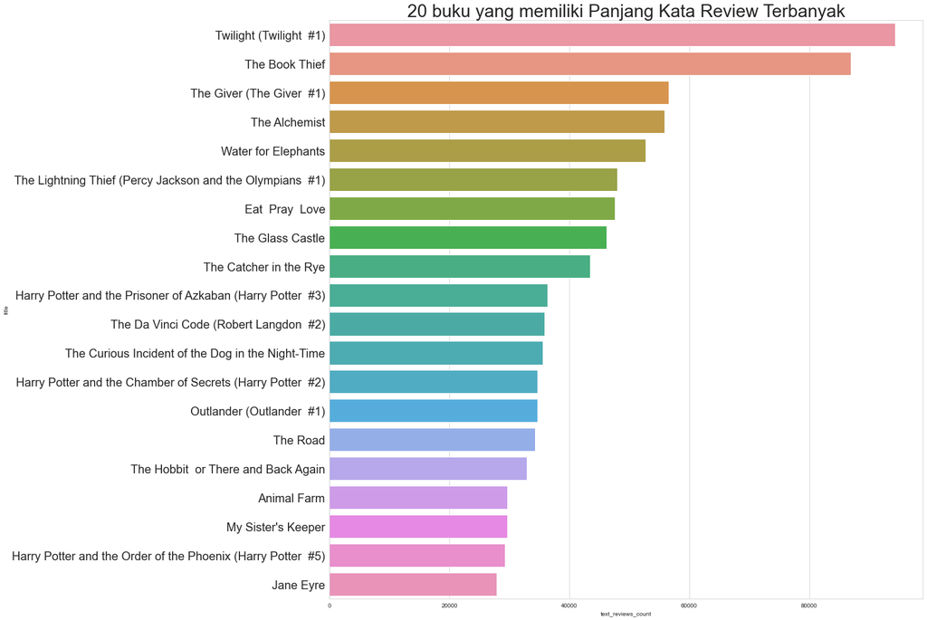

```python
e = df.sort_values(by='text_reviews_count', ascending=False).iloc[:20, :]
plt.figure(figsize=(18, 18))
ax = sns.barplot(x="text_reviews_count", y="title", data=e)
plt.title('20 buku yang memiliki Panjang Kata Review Terbanyak', fontsize=30)
plt.yticks(fontsize=20)
plt.show()
```

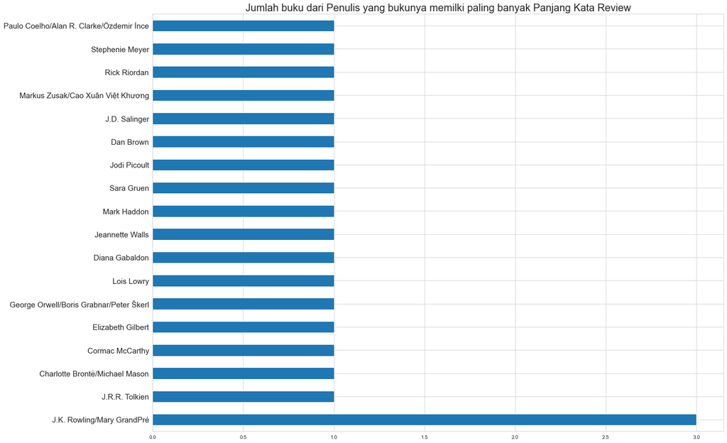

```python
plt.figure(figsize=(20, 15))
e['authors'].value_counts().plot(kind='barh')
plt.title('Jumlah buku dari Penulis yang bukunya memilki paling banyak Panjang Kata Review', fontsize=20)
plt.yticks(fontsize=15)
plt.show()
```

J.K. Rowling/Mary GrandPre memiliki 3 buku yang paling banyak Panjang Kata Review

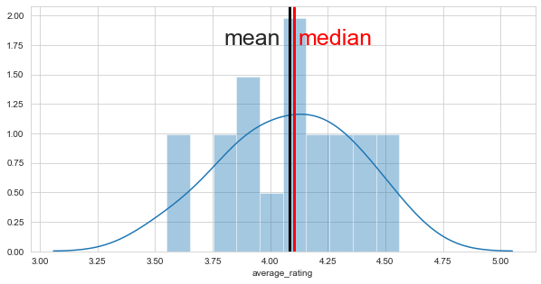

```python
plt.figure(figsize=(10, 5))
ax = sns.distplot(e['average_rating'], bins=10)
plt.text(3.8, 1.75, 'mean', fontsize=25,)
plt.axvline(x=e['average_rating'].mean(), linewidth=3, color = 'k')
plt.text(4.12, 1.75, 'median', fontsize=25, color='r')
plt.axvline(x=e['average_rating'].median(), linewidth=3, color = 'r')
plt.show()
```

Pada buku top 20 paling banyak Panjang Kata Review, rata-rata rating hampir membentuk distribusi Gaussian. Nilai mean dapat merepresentasikan berapa rata-rata dari average_rating buku yang memiliki banyak halaman

```python
d['average_rating'].mean()
```

```
4.43
```

Buku-buku yang paling banyak memiliki halaman memiliki average_rating rata-rata 4.43

### Dari Jumlah buku yang paling banyak di rating adakah hubungannya dengan rata-rata rating (average_rating)?

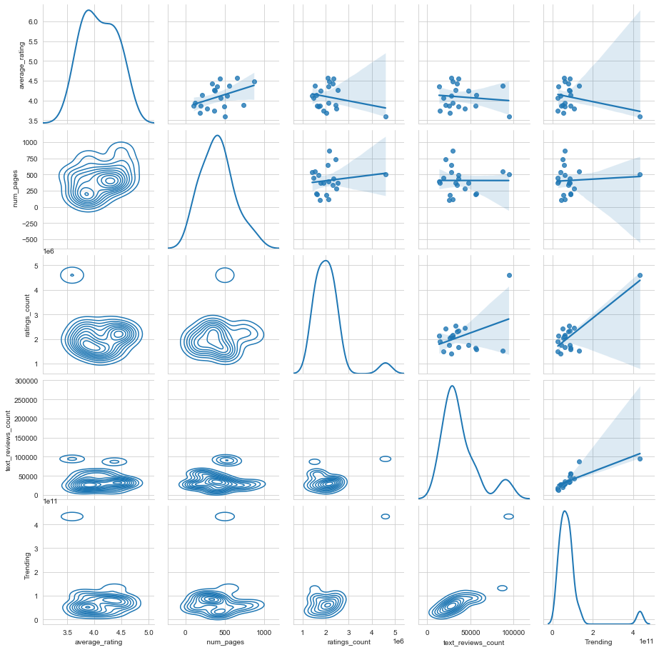

```python
g = sns.PairGrid(c.drop(columns=['Tanggal', 'Month', 'Year', 'bookID', 'isbn13']), diag_sharey=False)
g.map_upper(sns.regplot)
g.map_lower(sns.kdeplot, colors="C0")
g.map_diag(sns.kdeplot, lw=2)
```

Semakin banyak jumlah halaman semakin baik ratingnya, namun semakin banyak jumlah orang yang memberikan rating dan memberikan komentar review akan semakin kecil ratingnya

# Kesimpulan

```python
d = df.sort_values(by='  num_pages', ascending=False).iloc[:20, :]
new_table = pd.concat([c, d, e])
new_table
```

|  | bookID | title | authors | average_rating | isbn | isbn13 | language_code | num_pages | ratings_count | text_reviews_count | publication_date | publisher | Tanggal | Month | Year | Trending |
| --- | --- | --- | --- | --- | --- | --- | --- | --- | --- | --- | --- | --- | --- | --- | --- | --- |
| 10336 | 41865 | Twilight (Twilight #1) | Stephenie Meyer | 3.59 | 0316015849 | 9780316015844 | eng | 501 | 4597666 | 94265 | 2006-09-06 | Little Brown and Company | 6 | 9 | 2006 | 433398985490 |
| 1697 | 5907 | The Hobbit or There and Back Again | J.R.R. Tolkien | 4.27 | 0618260307 | 9780618260300 | eng | 366 | 2530894 | 32871 | 2002-08-15 | Houghton Mifflin | 15 | 8 | 2002 | 83193016674 |
| 1462 | 5107 | The Catcher in the Rye | J.D. Salinger | 3.80 | 0316769177 | 9780316769174 | eng | 277 | 2457092 | 43499 | 2001-01-30 | Back Bay Books | 30 | 1 | 2001 | 106881044908 |
| 307 | 960 | Angels & Demons (Robert Langdon #1) | Dan Brown | 3.89 | 1416524797 | 9781416524793 | eng | 736 | 2418736 | 21303 | 2006-04-01 | Pocket Books | 1 | 4 | 2006 | 51526333008 |
| 3 | 5 | Harry Potter and the Prisoner of Azkaban (Harr... | J.K. Rowling/Mary GrandPré | 4.56 | 043965548X | 9780439655484 | eng | 435 | 2339585 | 36325 | 2004-05-01 | Scholastic Inc. | 1 | 5 | 2004 | 84985425125 |
| 4415 | 15881 | Harry Potter and the Chamber of Secrets (Harry... | J.K. Rowling/Mary GrandPré | 4.42 | 0439064864 | 9780439064866 | eng | 341 | 2293963 | 34692 | 1999-06-02 | Arthur A. Levine Books / Scholastic Inc. | 2 | 6 | 1999 | 79582164396 |
| 1 | 2 | Harry Potter and the Order of the Phoenix (Har... | J.K. Rowling/Mary GrandPré | 4.49 | 0439358078 | 9780439358071 | eng | 870 | 2153167 | 29221 | 2004-09-01 | Scholastic Inc. | 1 | 9 | 2004 | 62917692907 |
| 23 | 34 | The Fellowship of the Ring (The Lord of the Ri... | J.R.R. Tolkien | 4.36 | 0618346252 | 9780618346257 | eng | 398 | 2128944 | 13670 | 2003-09-05 | Houghton Mifflin Harcourt | 5 | 9 | 2003 | 29102664480 |
| 2114 | 7613 | Animal Farm | George Orwell/Boris Grabnar/Peter Škerl | 3.93 | 0452284244 | 9780452284241 | eng | 122 | 2111750 | 29677 | 2003-05-06 | NAL | 6 | 5 | 2003 | 62670404750 |
| 0 | 1 | Harry Potter and the Half-Blood Prince (Harry ... | J.K. Rowling/Mary GrandPré | 4.57 | 0439785960 | 9780439785969 | eng | 652 | 2095690 | 27591 | 2006-09-16 | Scholastic Inc. | 16 | 9 | 2006 | 57822182790 |
| 2116 | 7624 | Lord of the Flies | William Golding | 3.68 | 0140283331 | 9780140283334 | eng | 182 | 2036679 | 26199 | 1999-10-01 | Penguin Books | 1 | 10 | 1999 | 53358953121 |
| 5015 | 18135 | Romeo and Juliet | William Shakespeare/Paul Werstine/Barbara A. M... | 3.74 | 0743477111 | 9780743477116 | eng | 368 | 1893917 | 14637 | 2004-01-01 | Simon Schuster | 1 | 1 | 2004 | 27721263129 |
| 7309 | 28187 | The Lightning Thief (Percy Jackson and the Oly... | Rick Riordan | 4.25 | 0786838655 | 9780786838653 | eng | 375 | 1766725 | 47951 | 2006-03-01 | Disney Hyperion Books | 1 | 3 | 2006 | 84716230475 |
| 294 | 890 | Of Mice and Men | John Steinbeck | 3.87 | 0142000671 | 9780142000670 | eng | 103 | 1755253 | 25554 | 2002-01-08 | Penguin Books | 8 | 1 | 2002 | 44853735162 |
| 310 | 968 | The Da Vinci Code (Robert Langdon #2) | Dan Brown | 3.84 | 0307277674 | 9780307277671 | eng | 489 | 1679706 | 35877 | 2006-03-28 | Anchor | 28 | 3 | 2006 | 60262812162 |
| 284 | 865 | The Alchemist | Paulo Coelho/Alan R. Clarke/Özdemir İnce | 3.86 | 0061122416 | 9780061122415 | eng | 197 | 1631221 | 55843 | 1993-05-01 | HarperCollins | 1 | 5 | 1993 | 91092274303 |
| 1069 | 3636 | The Giver (The Giver #1) | Lois Lowry | 4.13 | 0385732554 | 9780385732550 | eng | 208 | 1585589 | 56604 | 2006-01-24 | Ember | 24 | 1 | 2006 | 89750679756 |
| 5270 | 19063 | The Book Thief | Markus Zusak/Cao Xuân Việt Khương | 4.37 | 0375831002 | 9780375831003 | eng | 552 | 1516367 | 86881 | 2006-03-14 | Alfred A. Knopf | 14 | 3 | 2006 | 131743481327 |
| 591 | 1934 | Little Women | Louisa May Alcott | 4.07 | 0451529308 | 9780451529305 | eng | 449 | 1479727 | 18458 | 2004-04-06 | Signet Classics | 6 | 4 | 2004 | 27312800966 |
| 2764 | 10210 | Jane Eyre | Charlotte Brontë/Michael Mason | 4.12 | 0142437204 | 9780142437209 | eng | 532 | 1409369 | 27884 | 2003-02-04 | Penguin | 4 | 2 | 2003 | 39298845196 |
| 6497 | 24520 | The Complete Aubrey/Maturin Novels (5 Volumes) | Patrick O'Brian | 4.70 | 039306011X | 9780393060119 | eng | 6576 | 1338 | 81 | 2004-10-17 | W. W. Norton Company | 17 | 10 | 2004 | 108378 |
| 6802 | 25587 | The Second World War | Winston S. Churchill/John Keegan | 4.45 | 039541685X | 9780395416853 | eng | 4736 | 1493 | 99 | 1986-05-09 | Mariner Books | 9 | 5 | 1986 | 147807 |
| 10906 | 44613 | Remembrance of Things Past (Boxed Set) | Marcel Proust/C.K. Scott Moncrieff/Frederick A... | 4.34 | 0701125594 | 9780701125592 | eng | 3400 | 6 | 1 | 1981-03-05 | Chatto & Windus | 5 | 3 | 1981 | 6 |
| 6 | 10 | Harry Potter Collection (Harry Potter #1-6) | J.K. Rowling | 4.73 | 0439827604 | 9780439827607 | eng | 3342 | 28242 | 808 | 2005-09-12 | Scholastic | 12 | 9 | 2005 | 22819536 |
| 6822 | 25709 | Summa Theologica 5 Vols | Thomas Aquinas | 4.12 | 0870610635 | 9780870610639 | eng | 3020 | 2734 | 84 | 1981-01-01 | Christian Classics | 1 | 1 | 1981 | 229656 |
| 7862 | 30258 | Harrison's Principles of Internal Medicine | Dennis L. Kasper/Dan L. Longo/Stephen L. Hause... | 4.35 | 0071391401 | 9780071391405 | eng | 2751 | 23 | 4 | 2004-07-27 | McGraw-Hill Medical Publishing | 27 | 7 | 2004 | 92 |
| 4 | 8 | Harry Potter Boxed Set Books 1-5 (Harry Potte... | J.K. Rowling/Mary GrandPré | 4.78 | 0439682584 | 9780439682589 | eng | 2690 | 41428 | 164 | 2004-09-13 | Scholastic | 13 | 9 | 2004 | 6794192 |
| 10749 | 43888 | The Sword of Truth Boxed Set I: Wizard's Firs... | Terry Goodkind | 4.29 | 0812575601 | 9780812575606 | en-US | 2480 | 4196 | 81 | 1998-11-15 | Tor Books | 15 | 11 | 1998 | 339876 |
| 6257 | 23589 | The J.R.R. Tolkien Companion and Guide | Christina Scull/Wayne G. Hammond | 4.64 | 0618391134 | 9780618391134 | eng | 2264 | 45 | 0 | 2006-11-02 | Houghton Mifflin Harcourt | 2 | 11 | 2006 | 0 |
| 5614 | 20749 | Study Bible: NIV | Anonymous | 4.70 | 0310929555 | 9780310929550 | eng | 2198 | 4166 | 186 | 2002-10-01 | Zondervan Publishing House | 1 | 10 | 2002 | 774876 |
| 1053 | 3579 | The Complete Anne of Green Gables Boxed Set (A... | L.M. Montgomery | 4.43 | 0553609416 | 76783609419 | eng | 2088 | 98611 | 1447 | 1998-10-06 | Starfire | 6 | 10 | 1998 | 142690117 |
| 9929 | 40012 | Goodman & Gilman's the Pharmacological Basis o... | Laurence L. Brunton/John S. Lazo/Keith L. Parker | 4.29 | 0071422803 | 9780071422802 | eng | 2021 | 185 | 8 | 2005-09-21 | McGraw-Hill Professional Publishing | 21 | 9 | 2005 | 1480 |
| 5377 | 19406 | The Decline and Fall of the Roman Empire | Edward Gibbon | 3.98 | 1857151925 | 9781857151923 | eng | 1952 | 19 | 1 | 1994-10-01 | Everyman Chess | 1 | 10 | 1994 | 19 |
| 1056 | 3582 | The New Annotated Sherlock Holmes: The Complet... | Arthur Conan Doyle/Leslie S. Klinger | 4.64 | 0393059162 | 9780393059168 | eng | 1878 | 1411 | 54 | 2004-11-30 | W. W. Norton & Company | 30 | 11 | 2004 | 76194 |
| 4832 | 17341 | The Collected Letters of C.S. Lewis Volume 3:... | C.S. Lewis/Walter Hooper | 4.47 | 0060819227 | 9780060819224 | eng | 1840 | 144 | 16 | 2007-01-09 | HarperOne | 9 | 1 | 2007 | 2304 |
| 2566 | 9462 | Plato: Complete Works | Plato/John M. Cooper/Benjamin Jowett/Dorothea ... | 4.35 | 0872203492 | 9780872203495 | eng | 1838 | 9284 | 133 | 1997-05-01 | Hackett Publishing Company Inc. | 1 | 5 | 1997 | 1234772 |
| 420 | 1417 | The Complete Pelican Shakespeare | William Shakespeare/Stephen Orgel/A.R. Braunmu... | 4.50 | 0141000589 | 9780141000589 | eng | 1808 | 578 | 25 | 2002-11-07 | Viking | 7 | 11 | 2002 | 14450 |
| 7742 | 29906 | The Collected Dialogues | Plato/Edith Hamilton/Huntington Cairns | 4.23 | 0691097186 | 9780691097183 | eng | 1776 | 704 | 31 | 1963-09-15 | Princeton University Press (NJ) | 15 | 9 | 1963 | 21824 |
| 4867 | 17582 | The Norton Anthology of Short Fiction | Richard Bausch | 4.18 | 0393926117 | 9780393926118 | en-US | 1776 | 663 | 15 | 2006-01-05 | W. W. Norton & Company | 5 | 1 | 2006 | 9945 |
| 5279 | 19082 | The Complete Works: The Revised Oxford Transla... | Aristotle/Jonathan Barnes | 4.43 | 0691099502 | 9780691099507 | eng | 1757 | 2318 | 17 | 1984-09-01 | Bollingen/Princeton University Press (NJ) | 1 | 9 | 1984 | 39406 |
| 10336 | 41865 | Twilight (Twilight #1) | Stephenie Meyer | 3.59 | 0316015849 | 9780316015844 | eng | 501 | 4597666 | 94265 | 2006-09-06 | Little Brown and Company | 6 | 9 | 2006 | 433398985490 |
| 5270 | 19063 | The Book Thief | Markus Zusak/Cao Xuân Việt Khương | 4.37 | 0375831002 | 9780375831003 | eng | 552 | 1516367 | 86881 | 2006-03-14 | Alfred A. Knopf | 14 | 3 | 2006 | 131743481327 |
| 1069 | 3636 | The Giver (The Giver #1) | Lois Lowry | 4.13 | 0385732554 | 9780385732550 | eng | 208 | 1585589 | 56604 | 2006-01-24 | Ember | 24 | 1 | 2006 | 89750679756 |
| 284 | 865 | The Alchemist | Paulo Coelho/Alan R. Clarke/Özdemir İnce | 3.86 | 0061122416 | 9780061122415 | eng | 197 | 1631221 | 55843 | 1993-05-01 | HarperCollins | 1 | 5 | 1993 | 91092274303 |
| 10700 | 43641 | Water for Elephants | Sara Gruen | 4.09 | 1565125606 | 9781565125605 | eng | 335 | 1260027 | 52759 | 2007-05-01 | Algonquin Books | 1 | 5 | 2007 | 66477764493 |
| 7309 | 28187 | The Lightning Thief (Percy Jackson and the Oly... | Rick Riordan | 4.25 | 0786838655 | 9780786838653 | eng | 375 | 1766725 | 47951 | 2006-03-01 | Disney Hyperion Books | 1 | 3 | 2006 | 84716230475 |
| 5407 | 19501 | Eat Pray Love | Elizabeth Gilbert | 3.55 | 0143038419 | 9780143038412 | eng | 368 | 1362264 | 47620 | 2007-02-01 | Riverhead Books | 1 | 2 | 2007 | 64871011680 |
| 2060 | 7445 | The Glass Castle | Jeannette Walls | 4.27 | 074324754X | 9780743247542 | eng | 288 | 808656 | 46176 | 2006-01-17 | Scribner | 17 | 1 | 2006 | 37340499456 |
| 1462 | 5107 | The Catcher in the Rye | J.D. Salinger | 3.80 | 0316769177 | 9780316769174 | eng | 277 | 2457092 | 43499 | 2001-01-30 | Back Bay Books | 30 | 1 | 2001 | 106881044908 |
| 3 | 5 | Harry Potter and the Prisoner of Azkaban (Harr... | J.K. Rowling/Mary GrandPré | 4.56 | 043965548X | 9780439655484 | eng | 435 | 2339585 | 36325 | 2004-05-01 | Scholastic Inc. | 1 | 5 | 2004 | 84985425125 |
| 310 | 968 | The Da Vinci Code (Robert Langdon #2) | Dan Brown | 3.84 | 0307277674 | 9780307277671 | eng | 489 | 1679706 | 35877 | 2006-03-28 | Anchor | 28 | 3 | 2006 | 60262812162 |
| 514 | 1618 | The Curious Incident of the Dog in the Night-Time | Mark Haddon | 3.88 | 1400032717 | 9781400032716 | eng | 226 | 1054308 | 35537 | 2004-05-18 | Vintage | 18 | 5 | 2004 | 37466943396 |
| 4415 | 15881 | Harry Potter and the Chamber of Secrets (Harry... | J.K. Rowling/Mary GrandPré | 4.42 | 0439064864 | 9780439064866 | eng | 341 | 2293963 | 34692 | 1999-06-02 | Arthur A. Levine Books / Scholastic Inc. | 2 | 6 | 1999 | 79582164396 |
| 2959 | 10964 | Outlander (Outlander #1) | Diana Gabaldon | 4.23 | 0440242940 | 9780440242949 | eng | 850 | 673350 | 34690 | 2005-07-26 | Dell Publishing Company | 26 | 7 | 2005 | 23358511500 |
| 1782 | 6288 | The Road | Cormac McCarthy | 3.97 | 0307265439 | 9780307265432 | eng | 241 | 606433 | 34301 | 2006-09-26 | Alfred A. Knopf | 26 | 9 | 2006 | 20801258333 |
| 1697 | 5907 | The Hobbit or There and Back Again | J.R.R. Tolkien | 4.27 | 0618260307 | 9780618260300 | eng | 366 | 2530894 | 32871 | 2002-08-15 | Houghton Mifflin | 15 | 8 | 2002 | 83193016674 |
| 2114 | 7613 | Animal Farm | George Orwell/Boris Grabnar/Peter Škerl | 3.93 | 0452284244 | 9780452284241 | eng | 122 | 2111750 | 29677 | 2003-05-06 | NAL | 6 | 5 | 2003 | 62670404750 |
| 2951 | 10917 | My Sister's Keeper | Jodi Picoult | 4.07 | 0743454537 | 9780743454537 | eng | 423 | 986711 | 29652 | 2005-02-01 | Washington Square Press | 1 | 2 | 2005 | 29257954572 |
| 1 | 2 | Harry Potter and the Order of the Phoenix (Har... | J.K. Rowling/Mary GrandPré | 4.49 | 0439358078 | 9780439358071 | eng | 870 | 2153167 | 29221 | 2004-09-01 | Scholastic Inc. | 1 | 9 | 2004 | 62917692907 |
| 2764 | 10210 | Jane Eyre | Charlotte Brontë/Michael Mason | 4.12 | 0142437204 | 9780142437209 | eng | 532 | 1409369 | 27884 | 2003-02-04 | Penguin | 4 | 2 | 2003 | 39298845196 |

## Recommended Authors and Average Ratings

- Penulis buku Recommended yang selalu berada top 20 dinilai dari jumlah halaman buku, pembaca yang paling banyak memberikan rating, pembaca yang paling banyak memberikan review buku adalah sebagai berikut.

```python
new_table.groupby(['authors'])['average_rating'].mean().sort_values(ascending=False)
```

[output not shown]

[output cut: 25 more lines]

## Recommended Books and Average Ratings

```python
new_table.groupby(['title'])['average_rating'].mean().sort_values(ascending=False)
```

```
title
Harry Potter Boxed Set  Books 1-5 (Harry Potter  #1-5)                                                            4.78
Harry Potter Collection (Harry Potter  #1-6)                                                                      4.73
Study Bible: NIV                                                                                                  4.70
The Complete Aubrey/Maturin Novels (5 Volumes)                                                                    4.70
The New Annotated Sherlock Holmes: The Complete Short Stories                                                     4.64
The J.R.R. Tolkien Companion and Guide                                                                            4.64
Harry Potter and the Half-Blood Prince (Harry Potter  #6)                                                         4.57
Harry Potter and the Prisoner of Azkaban (Harry Potter  #3)                                                       4.56
The Complete Pelican Shakespeare                                                                                  4.50
Harry Potter and the Order of the Phoenix (Harry Potter  #5)                                                      4.49
The Collected Letters of C.S. Lewis  Volume 3: Narnia  Cambridge  and Joy  1950 - 1963                            4.47
The Second World War                                                                                              4.45
The Complete Works: The Revised Oxford Translation  Vol. 1                                                        4.43
The Complete Anne of Green Gables Boxed Set (Anne of Green Gables  #1-8)                                          4.43
Harry Potter and the Chamber of Secrets (Harry Potter  #2)                                                        4.42
The Book Thief                                                                                                    4.37
The Fellowship of the Ring (The Lord of the Rings  #1)                                                            4.36
Harrison's Principles of Internal Medicine                                                                        4.35
Plato: Complete Works                                                                                             4.35
Remembrance of Things Past (Boxed Set)                                                                            4.34
Goodman & Gilman's the Pharmacological Basis of Therapeutics                                                      4.29
The Sword of Truth  Boxed Set I: Wizard's First Rule  Blood of the Fold  Stone of Tears (Sword of Truth  #1-3)    4.29
The Glass Castle                                                                                                  4.27
The Hobbit  or There and Back Again                                                                               4.27
The Lightning Thief (Percy Jackson and the Olympians  #1)                                                         4.25
The Collected Dialogues                                                                                           4.23
Outlander (Outlander  #1)                                                                                         4.23
The Norton Anthology of Short Fiction                                                                             4.18
The Giver (The Giver  #1)                                                                                         4.13
Jane Eyre                                                                                                         4.12
Summa Theologica  5 Vols                                                                                          4.12
Water for Elephants                                                                                               4.09
My Sister's Keeper                                                                                                4.07
Little Women                                                                                                      4.07
The Decline and Fall of the Roman Empire                                                                          3.98
The Road                                                                                                          3.97
Animal Farm                                                                                                       3.93
Angels & Demons (Robert Langdon  #1)                                                                              3.89
The Curious Incident of the Dog in the Night-Time                                                                 3.88
Of Mice and Men                                                                                                   3.87
The Alchemist                                                                                                     3.86
The Da Vinci Code (Robert Langdon  #2)                                                                            3.84
The Catcher in the Rye                                                                                            3.80
Romeo and Juliet                                                                                                  3.74
Lord of the Flies                                                                                                 3.68
Twilight (Twilight  #1)                                                                                           3.59
Eat  Pray  Love                                                                                                   3.55
Name: average_rating, dtype: float64
```

## Trusted Rating

Dari hasil analisis rata-rata rating top 20 dari feature ' num_pages', 'ratings_count', dan 'text_reviews_count' didapatkan nilai rentang Trusted Rating di Goodreads adalah buku dengan Rating bernilai minimal 3.55.